# Recap: Part 2

Description and Inference

Ranadeep Daw

2024-08-27

## Lecture Outline

- Recap of summarization tools
- Computation
- Inference

# Data Summarization

## Topics

- Range
- Quantiles
  - Percentiles
  - Quartiles
  - Inter-quantile range
  - Boxplot
- Outliers

## Range

- *Definition:* The difference between the highest and lowest measurements in a group of data:

  Range = Largest data - smallest data.
- $\texttt{R}$ syntax: Use $\texttt{max(...) - min(...)}$, **not $\texttt{range(...)}$**.

```r
lifespan = c(39, 50, 82, 37, 42, 40, 41, 16, 32)
range(lifespan)
```

```
## [1] 16 82
```

```r
max(lifespan) - min(lifespan)
```

```
## [1] 66
```

## Quantiles

- Recall that half the data are above median, and rest of the data are below the median.
- Similarly, we define the $k$-th quantile of a data as the value below which $k$-th fraction of the data lies.
- $\texttt{R}$ syntax:

```r
quantile(vector, quantile)
```

## Percentiles

- *Notation*: The $k$-th percentile is denoted with $P_k$.
- *Definition*: $k\%$ of the data are less than or equal to $P_k$.
- *Note*: Median is the $50$-th percentile.
- *Example:* Finding $30$-th percentile of the lifespan example.

```r
lifespan = c(39, 50, 82, 37, 42, 40, 41, 16, 32)
quantile(lifespan, 0.30)
```

```
##  30%
## 37.8
```

## Quartiles

- When the data is divided into $4$ equal parts, we talk about quartiles:
  - $Q_1$: $\frac{1}{4}$ of all the data are $\leq$ 1st quartile.
  - $Q_2$: $\frac{1}{2}$ of all the data are $\leq$ 2nd quartile.
  - $Q_3$: $\frac{3}{4}$ of all the data are $\leq$ 3rd quartile.

## Quartiles vs Percentiles

- $Q_1$ is the $25$-th percentile (or $P_{25}$).
- $Q_2$ is the $50$-th percentile, or the median (or $P_{50}$).
- $Q_3$ is the $75$-th percentile (or $P_{75}$).

## Inter-quartile range (IQR)

- *Definition*: $IQR$ = 3rd Quartile - 1st Quartile = $Q_3 - Q_1$.
- $\texttt{R}$ syntax:

```r
quantile(<vector_name>, 0.25) #1st quartile
quantile(<vector_name>, 0.50) #2nd quartile
quantile(<vector_name>, 0.75) #3rd quartile
quantile(<vector_name>, c(0.25, 0.5, 0.75)) #All quartiles
IQR(<vector_name>)
```

## Boxplot

- A box plot (or box-and-whisker plot) displays the distribution of data based on a five-number summary: the minimum, first quartile ($Q_1$), median ($Q_2$), third quartile ($Q_3$), and maximum.
- Helps in plotting the quantiles and check *outliers*.
- $\texttt{R}$ syntax:

```r
boxplot(<vector_name>)
```

## Example:

- Let’s try the $\texttt{mtcars}$ data and plot the boxplot of the weights (column name $\texttt{wt}$).

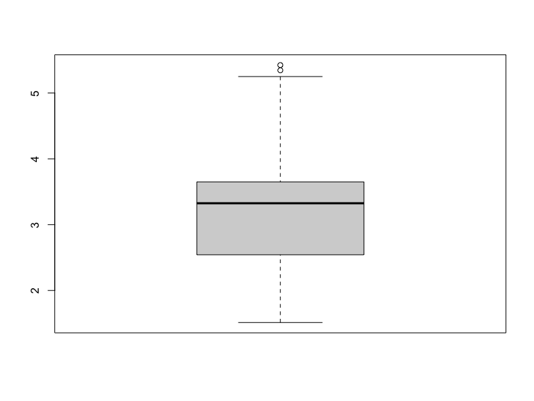

```r
data("mtcars")
weights = mtcars$wt
boxplot(weights)
```

## Check the answers

```r
quantile(weights, c(0.25, 0.5, 0.75)) # 3 quantiles
```

```
##     25%     50%     75%
## 2.58125 3.32500 3.61000
```

```r
cat("Min= ", min(weights), ", Max=", max(weights))
```

```
## Min=  1.513 , Max= 5.424
```

```r
cat("Upper fence: ", quantile(weights, 0.75) + 1.5 * IQR(weights))
```

```
## Upper fence:  5.153125
```

## Outliers

- *Definition*: An outlier is a data (or set of data points) that differs significantly from the other observations in the sample, raising doubts about whether it truly belongs to the sample.
- Outliers heavily effect some statistics, e.g., mean, variance, range.
- Median, IQR, quantiles are relatively robust to outliers.

## Example

- Suppose a dataset on 20-week-old mallard ducks shows the following record in kg: [^1].

  1.87,3.75,3.79,3.82,3.85,3.87.3.90.3.94,3.96,3.99, 3.99,4.00,4.03,4.04,4.05,4.06,4.09,8.97, 39.8
- Except the last point, the range of the data is between 1.87 and 8.97.
- Just by scanning, $39.8$ kg is clearly an outlier here.

## Quartile method for Outlier Detection

- We can detect outliers using quartiles and IQR:
  - Anything below lower fence = $Q_1 - 1.5*IQR$.
  - Anything above upper fence = $Q_3 + 1.5*IQR$.

## Example

```r
weights = c(1.87,3.75,3.79,3.82,3.85,3.87,3.90,3.94,3.96,3.99, 3.99,4.00,4.03,4.04,4.05,4.06,4.09,8.97,39.8)
Q_1 = quantile(weights, 0.25)
Q_3 = quantile(weights, 0.75)
iqr = IQR(weights)
outlier_lower_fence = Q_1 - 1.5* iqr #outlier lower bound
outlier_upper_fence = Q_3 + 1.5* iqr #outlier upper bound
outlier_lower_fence
```

```
##    25%
## 3.5825
```

```r
outlier_upper_fence
```

```
##    75%
## 4.3225
```

## Example (cont.)

- How many outliers on the lower side?
  - Anything below or lower than the lower fence.

```r
sum(weights < outlier_lower_fence)
```

```
## [1] 1
```

- How many outliers on the upper side?
  - Anything above or greater than the upper fence.

```r
sum(weights > outlier_upper_fence)
```

```
## [1] 2
```

## Example with $\texttt{boxplot}$

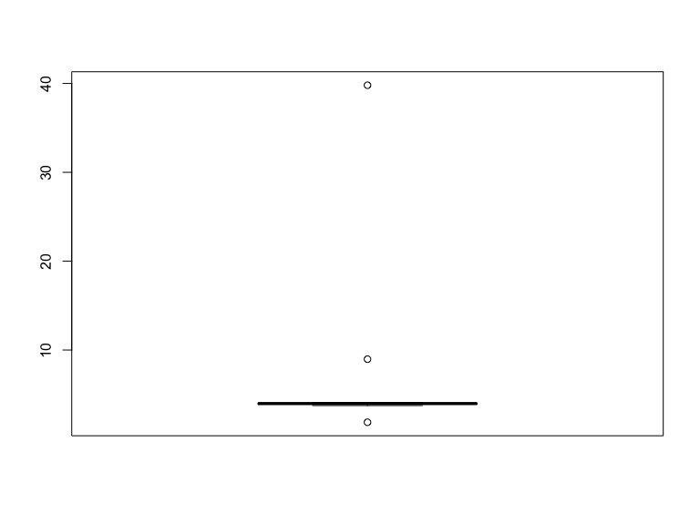

```r
boxplot(weights)
```

- Doesn’t show very well, but clearly detects the outliers.

## Effect of Outliers

- Heavy effect on mean, variance, range.
- Does not affect much median, IQR.

## Example with Duck Weights

```r
weights = c(1.87,3.75,3.79,3.82,3.85,3.87,3.90,3.94,3.96,3.99,
            3.99,4.00,4.03,4.04,4.05,4.06,4.09,8.97,39.8)
weights_no_outliers =  c(3.75,3.79,3.82,3.85,3.87,3.90,3.94,3.96,3.99,
                         3.99,4.00,4.03,4.04,4.05,4.06,4.09)
mean_with_outliers = mean(weights)
mean_without_outliers = mean(weights_no_outliers)
median_with_outliers  = median(weights)
median_without_outliers = median(weights_no_outliers)
cat("Mean with outliers = ", mean_with_outliers, "\n",
    "Mean without outliers = ", mean_without_outliers, "\n",
    "Median with outliers = ", median_with_outliers, "\n",
    "Median without outliers = ", median_without_outliers)
```

```
## Mean with outliers =  5.987895
##  Mean without outliers =  3.945625
##  Median with outliers =  3.99
##  Median without outliers =  3.975
```

## Example with duck weights

- Let’s compare the effect on variance, range, and inter-quartile range in class.
  - Variance - heavily affected.

```r
weights = c(1.87,3.75,3.79,3.82,3.85,3.87,3.90,3.94,3.96,3.99,
            3.99,4.00,4.03,4.04,4.05,4.06,4.09,8.97,39.8)
weights_no_outliers =  c(3.75,3.79,3.82,3.85,3.87,3.90,3.94,3.96,3.99,
                         3.99,4.00,4.03,4.04,4.05,4.06,4.09)

var(weights)
```

```
## [1] 68.66697
```

```r
var(weights_no_outliers)
```

```
## [1] 0.01087958
```

## IQR

IQR - not affected.

```r
IQR(weights) # Without outlier
```

```
## [1] 0.185
```

```r
IQR(weights_no_outliers) # With outlier
```

```
## [1] 0.1675
```

## Range

Range - again heavily affected.

## Summarization so far

- We learnt
  - Mean
  - Median
  - Variance, Standard deviation
  - Quantiles
  - IQR
  - Range
  - Outliers
  - Boxplot
- Still need to learn
  - Frequency table
  - Histogram

# Inference

## Why Inference?

- Can we analyze/ describe the grades data on the current UWF students?
  - Yes, UWF stores all the data.
- Can we analyze/ describe the data on salary of the past UWF students?
  - Unlikely for UWF to have ALL the data.

## Why Inference? (contd.)

- Q1: Suppose I tossed a coin 10 times. I got 6 Heads, 4 Tails. Is it fair (equal chance of heads or tails)?
  - So far, not enough evidence to say unfair.
- Q2: Now, suppose I tossed it 100 times. I got 64 Heads, 36 Tails. Is it still fair?
  - Slightly *likely* unfair.
- Q3: Now, suppose I tossed it 10000 times. I got 6348 Heads, 3652 Tails. Is it still fair?
  - Really *likely* unfair.

## Population vs Sample

1. **Population** is the entire group of data or objects about which one wishes to draw conclusions.
2. **Sample** is a subset of the population.
3. *Example:* Ecologists collected data on 100 grasshoppers over Pensacola and want to study the properties:
- *Population:* All the grasshoppers in Pensacola.
- *Sample:* Only the collected 100 grasshoppers.

## Population vs Sample (contd.)

- We usually don’t have access to the entire population.
- Samples are used to draw conclusions about population.
- This is the basis of statistical inference, where we draw conclusion about the unknown population from the sample.

## Parameter vs Statistic

- **Statistic**: A statistic is an entity that describes a characteristic of a sample.
  - Example: Sample mean, variance, median.
  - Given a sample, we typically know this.

## Parameter vs Statistic (cont.)

- **Parameter**: A quantity is called a parameter when it describes or characterizes the entire population.
  - Example: Population mean, population variance.
  - Since we don’t have access to the entire population, parameter is typically unknown to the statisticans.
  - We try to **estimate** a parameter with a sample statistic.

## Statistical Inference

Things to learn:

- Probability
- Probability Distribution
- Estimation
- Confidence intervals
- Hypothesis testing

## Probability

- A mathematical concept to analyze the chance or likelihood of an event/realization.
- Probability of an event:
  $$\mathbb{P}(E)
  = \frac{\text{Number of times the event can
  occurr/occurred}}{\text{Total number of possible
  outcomes}}$$
- Sample space ($\Omega$): A set of all possible events or realizations.

## Properties of Probability

1. $0 \leq \mathbb{P}(E) \leq 1$.
2. $\mathbb{P}(\Omega) = 1$.
3. Mutual exclusiveness: Two events $A$ and $B$ are mutually exclusive if $\mathbb{P}(A \text{ or } B) = \mathbb{P}(A) + \mathbb{P}(B)$.
- Example: Heads and Tails in a coin toss

## Random Variable and Probability Distribution

- Recall random variables - outcomes of an experiment.
- Suppose we have a variable $X$, with possible realizations (or sample space) $\Omega = \{x_1, \cdots, x_n\}$.
- Random variables assigns probability to each of the possible event/ realization as below:
  $$\begin{align*}
  p_1 &= \mathbb{P}(X = x_1) \\
  &\cdots \\
  p_n &= \mathbb{P}(X = x_n)
  \end{align*}$$

## Probability Distribution

- This is called the *Probability distribution* of the variable.
- Also we define:
  - Expectation or $\mathbb{E}(X)$: Mean of X.
  - Variance or $\mathbb{V}(X)$: Variance of X.

## Example: Coin toss

- *Variable*: $X$ = Outcome of a coin toss
- *Sample space*: $\Omega = H, T$.
- *Probability distribution*:
  $$\begin{align*}
  \mathbb{P}(X = H) = p \\
  \mathbb{P}(X = T) = 1-p \\
  \end{align*}$$

## Example: Die roll

- *Variable*: $X$ = Outcome of a die roll.
- *Sample space*: $\Omega = \{1, 2, 3, 4, 5, 6\}$.
- *Probability distribution*:
  $$\begin{align*}
  \mathbb{P}(X = 1) &= p_1\\
  \mathbb{P}(X = 2) &= p_2\\
  \mathbb{P}(X = 1) &= p_3\\
  \mathbb{P}(X = 2) &= p_4\\
  \mathbb{P}(X = 5) &= p_5\\
  \mathbb{P}(X = 6) &= p_6 = 1 - (p_1 + p_2 + p_3 + p_4 + p_5)
  \end{align*}$$

## Binomial Distribution: Coin toss

- Take the coin toss example. Suppose I am tossing it 10000 times and got 6348 Head, 3652 Tails.
- Each toss has **two** possible outcomes - H and T.
- Two different tosses are independent of each other, i.e., outcome of a new toss does not depend on the old toss.
- These are the conditions that are required for Binomial distribution (we will revisit in details later).

## Coin toss (contd.)

- We want to draw inference on the true probability of head, call it $p$.
- However, we can never know true value of $p$.
- Can we try to guess from our examples?
  - Yes, we can reasonably estimate the **population parameter** here with a **sample statistic**.

## Estimation of $p$: Coin toss examples

1. Case 1: $6$ heads out of $10$ tosses:
   $$\hat{p} = 6/10 = 0.6$$
2. Case 2: $64$ heads out of $100$ tosses:
   $$\hat{p} = 64/100 = 0.64$$
3. Case 3: $6348$ heads out of $10000$ tosses:
   $$\hat{p} = 6348/10000 = 0.6348$$

## Note

- Our guess or estimation can never be exactly correct, but it may “tell a story” about the chance of head.
  - “All models are wrong, but some are useful.” ~ George E. P. Box
- True $p$ is still never known.
  - Never write $p = 0.6$ since this is unknown.
  - Always write $\hat{p} = 0.6$, since you estimate this from the data.

## Note (cont.)

- If we draw different samples from the same population, the population parameter remains the same.
- The sample estimates change with different samples.
- A good sample and a reasonable estimator together can give us some idea about the truth:
  - We can estimate the probability of head with $\hat{p} = 5$, but it’s not a reasonable one.
  - We can use a sample of athletes to analyze average blood cholesterol content over the USA, but it is not a good representative sample.

## Next Class

- How can we quantify how good estimates are?
  - Confidence interval
- Hypothesis testing
- Normal distribution - even easier to deal than binomial example.
[^1]: source: Biostatistical Analysis, Prentice Hall